# *treeWAS* Vignette

Caitlin Collins

2019-04-24

## Introduction

The *treeWAS* R package allows users to apply our phylogenetic tree-based appraoch to Genome-Wide Association Studies (GWAS) to microbial genetic and phenotypic data. In short, *treeWAS* measures the statistical association between a phenotype of interest and the genotype at all loci, with the aim of identifying significant associations, while correcting for the confounding effects of clonal population structure and homologous recombination. *treeWAS* is applicable to both bacterial and viral genetic data from both the core and accessory genomes, and to both binary and continuous phenotypes.

## Installation

*treeWAS* is currently being hosted on GitHub at https://github.com/caitiecollins/treeWAS.

The most up-to-date version of *treeWAS* can be easily installed directly within R, using the `devtools` package.

```r
## install devtools, if necessary:
install.packages("devtools", dep=TRUE)
library(devtools)

## install treeWAS from github:
install_github("caitiecollins/treeWAS", build_vignettes = TRUE, force=TRUE)
library(treeWAS)
```

To open the vignette from within R (recommended if any formatted elements are not rendering properly where you are currently reading this), run `browseVignettes` and click on the `HTML` hyperlink:

```r
browseVignettes("treeWAS")
```

## The *treeWAS* Approach

The approach adopted within *treeWAS* is described fully in our paper, available in [PLOS Computational Biology](http://journals.plos.org/ploscompbiol/article?id=10.1371/journal.pcbi.1005958).

As a GWAS approach, *treeWAS* performs an unbiased search for statistically significant associations between a phenotype of interest and the genotype at all loci in a genetic dataset. No prior hypotheses about potential associations at candidate loci are required. Instead, a statistical approach is used to compare the genomes of individuals and to identify systematic differences in genotype that correspond to differences in the phenotype.

In addition to measuring associations and identifying statistically-significant findings, a central aim of *treeWAS* is to control for the confounding effects of clonal population structure and population stratification (overlap between the genetic ancestry and phenotypic states of individuals that gives rise to spurious associations) and homologous recombination. Our approach uses data simulation to disentangle genuine associations, with statistical significance and evolutionary support, from the noisy background of spurious associations arising by chance and from confounding factors. *treeWAS* simulates a “null” genetic dataset in such a way as to maintain several features of the empirical dataset, namely: its clonal genealogy, terminal phenotype, genetic composition, and homoplasy distribution (the number of substitutions per site due to both mutation and recombination). The simulated dataset is therefore able to capture these potentially-confounding features of the dataset under analysis, but without recreating any of the “true” associations, beyond those expected to arise by chance or as a result of these confounding factors.

Once the “null” genetic dataset has been generated, *treeWAS* can calculate association scores for loci in both the real and simulated datasets and compare the two. The association between each simulated locus and the empirical phenotype is measured and, collectively, these values form a null distribution of association score statistics. The degree of association between each locus in the empirical genetic dataset and the empirical phenotype is measured using the same association scores. At the upper tail of the null distribution, a threshold of significance is drawn at the quantile corresponding to: 1 - (a base p-value corrected for multiple testing). Any loci in the real dataset that have association score values lying above this threshold are deemed to be significantly associated to the phenotype.

### Tests of Association

When measuring association between the phenotype of interest and the genotype, by default, three separate association scores are calculated for each locus in the genetic dataset.

*Equations below use the following notation:*

- $g$ = Genotypic state…
- $p$ = Phenotypic state…
- $anc$ = … at ancestral nodes
- $des$ = … at descendant nodes
- $n_{term}$ = Number of terminal nodes
- $n_{branch}$ = Number of branches

> **Terminal**

> The `terminal` test solves the following equation, for each genetic locus, at the terminal nodes of the tree only:
> $$\begin{align}
> Terminal = | \sum_{i = 1}^{n_{term}}\frac{1}{n_{term}}(&p_{i}^{des}g_{i}^{des}\ -\ (1 - p_{i}^{des})g_{i}^{des}\ -\ \\
> &p_{i}^{des}(1 - g_{i}^{des})\ +\ (1 - p_{i}^{des})(1 - g_{i}^{des}))\ |
> \end{align}$$

> The `terminal` test is a sample-wide test of association that seeks to identify broad patterns of correlation between genetic loci and the phenotype, without relying on inferences drawn from reconstructions of the ancestral states.

> **Simultaneous**

> The `simultaneous` test solves the following equation, for each genetic locus, across each branch in the tree.
> $$\begin{align}
> Simultaneous = |\sum_{i = 1}^{n_{branch}}(p_i^{anc} - p_i^{des})(g_i^{anc} - g_i^{des})\ |
> \end{align}$$

> This allows for the identification of simultaneous substitutions in both the genetic locus and phenotypic variable on the same branch of the phylogenetic tree (or parallel change in non-binary data). Simultaneous substitutions are an indicator of a deterministic relationship between genotype and phenotype. Moreover, because this score is not negatively impacted by the lack of association on other branches, it may be able to detect associations occurring through complementary pathways (i.e., in some clades but not others).

> **Subsequent**

> The `subsequent` test solves the following equation, for each genetic locus, across each branch in the tree:
> $$\begin{align}
> Subsequent = |\sum_{i = 1}^{n_{branch}}\ \
> (&\frac{4}{3}(p_i^{anc}g_i^{anc})\ +\ \frac{2}{3}(p_i^{anc}g_i^{des})\ +\ \\
> & \frac{2}{3}(p_i^{des}g_i^{anc})\ +\ \frac{4}{3}(p_i^{des}g_i^{des})\ -\ \\
> & p_i^{anc}\ -\ p_i^{des}\ -\ g_i^{anc}\ -\ g_i^{des}\ +\ 1)\ |
> \end{align}$$

> Calculating this metric across all branches of the tree allows us to measure in what proportion of tree branches we expect the genotype and phenotype to be in the same state. By drawing on inferences from the ancestral state reconstructions as well as the terminal states, this score may allows us to identify broad, if imperfect, patterns of association.

## Using the *treeWAS* R Package

Here we will go over the functions and arguments used within the *treeWAS* package. We will use a simple example dataset available within *treeWAS* to illustrate the code involved. Integration with the ClonalFrameML software will be discussed in a subsequent section.

## Data

### Required Elements

To carry out a GWAS using *treeWAS*, the following data is **required**:

> **A genetic dataset**

> A `matrix` containing binary genetic data (whether this encodes SNPs, gene presence/absence, etc. is up to you). Individuals should be in the rows, and genetic variables in the columns. Both rows and columns must be appropriately labelled with unique names.

> **A phenotypic variable**

> A `vector` or `factor` containing either a binary or continuous variable encoding the phenotype for each individual. Each element should have a name that corresponds to the row labels of the genetic data matrix (order does not matter).

### Optional Elements

The following **optional** elements can also be provided by the user or, alternatively, these can be generated automatically by the `treeWAS` function:

> **A phylogenetic tree**

> An object of class `phylo` (from the *ape* package), containing a phylogenetic tree. Tip labels are required and must correspond to both the row labels of the genetic data matrix and the names of the phenotypic variable. Any additional individuals, including the outgroup if not under analysis, should be removed prior to running *treeWAS*. The tree can be either rooted or unrooted.

> **An ancestral state reconstruction of the genotype**

> A `matrix` containing a reconstruction of the ancestral states of all loci in the genetic dataset, at all internal nodes. This should include the original states at the terminal nodes and have the same number of columns as the input genetic data matrix. The number of rows should be equal to the total number of nodes in the tree, including the terminal nodes (in rows 1:N). It must have been reconstructed with either parsimony or ML (see `?treeWAS`), and you must provide the tree, for consistency with the ancestral state reconstruction of the simulated genetic dataset that will be performed within *treeWAS*.

> **An ancestral state reconstruction of the phenotype**

> A `vector` or `factor` containing a reconstruction of the ancestral states of the phenotypic variable at all nodes in the tree, including the original states at the terminal nodes (at positions 1:N).

### Example Data

We will use the data stored within *treeWAS* as an example throughout this section of the vignette. We load the data using the `data` function and examine its structure below:

```r
## Load example data:
data(snps)
data(phen)
data(tree)
data(snps.reconstruction)

## Examine data:
## genetic data
str(snps)
```

```
##  num [1:100, 1:20003] 0 1 1 1 1 1 1 1 1 1 ...
##  - attr(*, "dimnames")=List of 2
##   ..$ : chr [1:100] "A_1090" "B_1078" "A_1070" "B_1083" ...
##   ..$ : chr [1:20003] "1.g" "1.a" "2.t" "2.g" ...
```

```r
## phenotype
str(phen)
```

```
##  Factor w/ 2 levels "A","B": 2 2 2 2 1 2 1 1 2 2 ...
##  - attr(*, "names")= chr [1:100] "B_1132" "B_1105" "B_1079" "B_1133" ...
```

```r
table(phen)
```

```
## phen
##  A  B
## 45 55
```

```r
## tree
str(tree)
```

```
## List of 5
##  $ edge       : int [1:198, 1:2] 167 167 150 150 168 168 184 184 190 190 ...
##  $ tip.label  : chr [1:100] "B_1132" "B_1105" "B_1079" "B_1133" ...
##  $ edge.length: num [1:198] 0.00884 0.00884 0.01584 0.01584 0.00863 ...
##  $ Nnode      : int 99
##  $ node.label : chr [1:99] "NODE_101" "NODE_102" "NODE_103" "NODE_104" ...
##  - attr(*, "class")= chr "phylo"
##  - attr(*, "order")= chr "pruningwise"
```

```r
## genetic data reconstruction:
str(snps.reconstruction)
```

```
##  num [1:199, 1:20003] 0 1 1 1 1 1 1 1 1 1 ...
##  - attr(*, "dimnames")=List of 2
##   ..$ : chr [1:199] "A_1090" "B_1078" "A_1070" "B_1083" ...
##   ..$ : chr [1:20003] "1.g" "1.a" "2.t" "2.g" ...
```

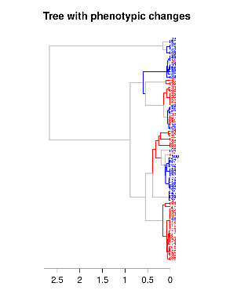

```r
## Load colours:
data(phen.plot.col)

## Plot tree showing phenotype:
p <- plot_phen(tree, phen.nodes=phen.plot.col$all.nodes)
```

## Data Cleaning

Before running the `treeWAS` function, please ensure that your data is in the appropriate format.

### Loading data:

The *ape* and *adegenet* packages loaded with *treeWAS* contain a number of functions useful for reading in data from a file and converting it. Some useful commands are included below.

For genetic data, the `read.dna` function can read in sequences from “sequential”, “CLUSTAL”, or “FASTA” formatted files. One way to convert the resulting `DNAbin` class object to a binary matrix is by way of the `DNAbin2genind` function.

```r
## (Template code, don't run)
## Read data from file:
dna <- read.dna(file = "filename", format = "fasta")

## Convert:
mat <- DNAbin2genind(dna)@tab
```

Then, see “Biallelic loci” below to remove redundant columns.

Phylogenetic trees can also be imported. Good tree-building programs exist outside of R, and we encourage users to provide a tree that has been built with external software, especially if the organism under analysis undergoes recombination (see the section below on “Integration with ClonalFrameML”). To read trees from file, `read.tree` can be used for trees stored in Newick/New Hampshire format and `read.nexus` for trees of Nexus format. Both return a `phylo` object, so no further conversion is required.

```r
## (Template code, don't run)
## Read tree from a Newick/New Hampshire file:
tree <- read.tree(file = "filename")

## Or from a Nexus file:
tree <- read.nexus(file = "filename")

## Convert:
mat <- DNAbin2genind(dna)@tab
```

Phenotypic data can be read in from a text or CSV file with `read.table`. Then, simply convert to a vector and retain the names.

```r
## (Template code, don't run)
## Read file:
df <- read.table(file="filename")

## Convert:
phen <- as.vector(unlist(df))
names(phen) <- rownames(df)
```

### Labels:

The genetic data matrix, phenotype, and phylogenetic tree (terminal nodes) should all be labelled with corresponding sets of names for the individuals.

Any individual that is not present in one or more of the genetic data matrix, the phenotypic variable, and/or the phylogenetic tree must be removed.

```r
## Check that labels are present:
is.null(tree$tip.label)
```

```
## [1] FALSE
```

```r
is.null(rownames(snps))
```

```
## [1] FALSE
```

```r
is.null(names(phen))
```

```
## [1] FALSE
```

```r
## Cross-check labels with each other:
all(tree$tip.label %in% rownames(snps))
```

```
## [1] TRUE
```

```r
all(rownames(snps) %in% tree$tip.label)
```

```
## [1] TRUE
```

```r
all(tree$tip.label %in% names(phen))
```

```
## [1] TRUE
```

```r
all(names(phen) %in% tree$tip.label)
```

```
## [1] TRUE
```

```r
all(names(phen) %in% rownames(snps))
```

```
## [1] TRUE
```

```r
all(rownames(snps) %in% names(phen))
```

```
## [1] TRUE
```

The above checks are run within `treeWAS`, but it may be worthwhile to confirm for yourself that all labels are present and look correct.

In addition, if either `snps.reconstruction` or `phen.reconstruction` is being provided as input, the user must ensure that `tree$node.label` contains labels for all internal nodes and that this same set of names is used to label the rows or indices correspondng to the internal nodes in `snps.reconstruction` and/or `phen.reconstruction`.

### Biallelic loci:

If, in the genetic data matrix, redundant columns are present for binary loci (i.e., Denoting the state of the second allele as the inverse of the previous column), these should be removed. For loci with more than two alleles, all columns should be retained.

The removal of redundant binary columns can be done by hand; but, the function `get.binary.snps` may also be used. This function requires column names to have a two-character suffix and unique locus identifiers. The function expects the suffixes “.a”, “.c”, “.g”, “.t” (e.g., “Locus_123243.a”, “Locus_123243.g”), though alternative two-character suffixes can be used (e.g., “Locus_123243_1”, “Locus_123243_2”) by setting the argument `force = TRUE`.

Please also be careful not to accidentally remove any purposeful duplications with repeated names, for example, if you have deliberately duplicated columns (e.g., by expanding unique columns according to an index returned by ClonalFrameML), assign unique column names before removing unwanted columns.

Before running the `get.binary.snps` function, you can check the suffixes of the genetic data matrix’s column names using another small function in *treeWAS*, `keepLastN`, which allows you to keep the last N characters of a variable or vector:

```r
suffixes <- keepLastN(colnames(snps), n = 2)
suffixes <- unique(suffixes)

if(all(suffixes %in% c(".a", ".c", ".g", ".t"))){
  ## SNPs:
  snps <- get.binary.snps(snps)

  ## ... Optional step (for snps.reconstruction, if present)
  ## (Example only, if needed for user data)
  if(is.matrix(snps.reconstruction)){
    snps.reconstruction <- snps.reconstruction[, which(colnames(snps.reconstruction) %in% colnames(snps))]
  }
}
```

### Missing data:

Missing data is permitted (denoted by `NA` values only) in the genetic data matrix. Any column that is entirely missing will be automatically removed within `treeWAS`. Any column composed of more than 75% NAs will also be removed; however, if for some reason you do not wish this to be the case, set the argument `na.rm` to `FALSE`.

Missing data is also permitted in the phenotype, although any missing individuals will be automatically removed from the analysis.

### Trees:

The phylogenetic tree, if provided by the user, should contain only the terminal nodes corresponding to the individuals under analysis. Any additional individuals, including the outgroup, if not under analysis should be removed prior to running *treeWAS*. The tree can be either rooted or unrooted.

### Continuous phenotypes:

If you are working with a continuous phenotype, you may be able to apply *treeWAS* to the phenotype directly.

But, if you are working with a particularly skewed phenotype or one with serious outliers, you may want to modify your data prior to running *treeWAS*. It is important to examine the distribution of your phenotype.

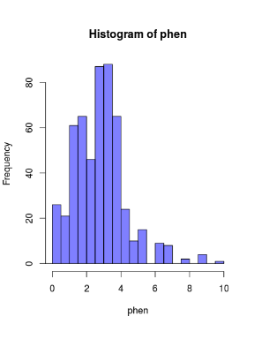

```r
## Load eg. variable:
data(phen.cont)

## Examine phen distribution:
hist(phen.cont)
```

Identify the ranks of your phenotypic values and examine the distribution of the phenotypic ranks.

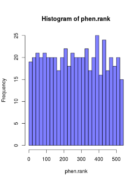

```r
## Get ranks of phen:
phen.cont.rank <- rank(phen.cont, ties.method = "average")
names(phen.cont.rank) <- names(phen.cont)

## Examine distribution of phen ranks:
hist(phen.cont.rank)
```

The phenotypic ranks are likely to have a more uniform distribution than the original values. Greater uniformity in this distribution will improve the performance of *treeWAS*. Consider replacing the phenotype with the ranks thereof.

```r
## Store original phen:
phen.cont.ori <- phen.cont

## Replace phen with ranks of phen:
phen.cont <- phen.cont.rank
```

If you choose not to transform the phenotype by rank, you may want to consider removing outliers if any are present, as these may similarly distort the analysis of continuous phenotypes.

## Arguments

The `treeWAS` function takes the following arguments:

```r
## Don't run this:
out <- treeWAS(snps,
                phen,
                tree = c("BIONJ", "NJ", "BIONJ*", "NJ*"),
                n.subs = NULL,
                n.snps.sim = ncol(snps)*10,
                chunk.size = ncol(snps),
                mem.im = FALSE,
                test = c("terminal", "simultaneous", "subsequent"),
                snps.reconstruction = "parsimony",
                snps.sim.reconstruction = "parsimony",
                phen.reconstruction = "parsimony",
                phen.type = NULL,
                na.rm = TRUE,
                p.value = 0.01,
                p.value.correct = c("bonf", "fdr", FALSE),
                p.value.by = c("count", "density"),
                dist.dna.model = "JC69",
                plot.tree = TRUE,
                plot.manhattan = TRUE,
                plot.null.dist = TRUE,
                plot.dist = FALSE,
                snps.assoc = NULL,
                filename.plot = NULL,
                seed = NULL)
```

> **`snps`**

> A matrix containing binary genetic data, with individuals in the rows and genetic loci in the columns and both rows and columns labelled.

> **`phen`**

> A vector containing the phenotypic state of each individual, whose length is equal to the number of rows in `snps` and which is named with the same set of labels. The phenotype can be either binary (character or numeric) or continuous (numeric).

> **`tree`**

> A `phylo` object containing the phylogenetic tree; or, a character string, one of `"NJ"`, `"BIONJ"` (the default), or `"parsimony"`; or, if NAs are present in the distance matrix, one of: `"NJ*"` or `"BIONJ*"`, specifying the method of phylogenetic reconstruction.

> **`n.subs`**

> A numeric vector containing the homoplasy distribution (if known, see details), or `NULL` (the default).

> **`n.snps.sim`**

> An integer specifying the number of loci to be simulated for estimating the null distribution (by default `10*ncol(snps)`). Note that 10x is the recommended *minimum*: where possible (i.e., for datasets that are not very large),  
> simulating *more* loci (e.g., `100*ncol(snps)`) may further improve results.

> **`chunk.size`**

> An integer indicating the number of `snps` loci to be analysed at one time. This provides a solution for machines with insufficient memory to analyse the dataset at hand. Note that smaller values of `chunk.size` will increase the computational time required (e.g., for `chunk.size = ncol(snps)/2`, treeWAS will take twice as long to complete).

> **`mem.lim`**

> Either a number or a logical value to establish a memory limit (in GB) that will be used to automatically update the `chunk.size` argument if there is not enough available memory to run treeWAS in one chunk. If `FALSE` (the default), no limit is estimated and `chunk.size` is not changed. If `TRUE`, the amount of memory currently available is estimated with `memfree()` and `chunk.size` is scaled back to account for the amount of memory estimated to be needed by treeWAS for this dataset. If a single numeric value, this is taken to be the amount of memory (in GB) available/designated for use by treeWAS and `chunk.size` is updated to reflect this.

> **`test`**

> A character string or vector containing one or more of the following available tests of association: `"terminal"`, `"simultaneous"`, `"subsequent"`, `"cor"`, `"fisher"`. By default, the first three tests are run (see details).

> **`snps.reconstruction`**

> Either a character string specifying `"parsimony"` (the default) or `"ML"` (maximum likelihood) for the ancestral state reconstruction of the genetic dataset, or a matrix containing this reconstruction if it has been performed elsewhere *and* you provide the tree.

> **`snps.sim.reconstruction`**

> A character string specifying `"parsimony"` (the default) or `"ML"` (maximum likelihood) for the ancestral state reconstruction of the simulated null genetic dataset.

> **`phen.reconstruction`**

> Either a character string specifying `"parsimony"` (the default) or `"ML"` (maximum likelihood) for the ancestral state reconstruction of the phenotypic variable, or a vector containing this reconstruction if it has been performed elsewhere.

> **`phen.type`**

> An optional character string specifying whether the ancestral state reconstruction of the phenotypic variable, if performed via ML, should treat the phenotype as either `"discrete"` or `"continuous"`. By default, `phen.type` is `NULL`, in which case ML reconstructions will be `"continuous"` for any non-binary phenotypes.

> **`na.rm`**

> A logical indicating whether to remove `snps` columns if they contain more than 75% NAs (by default, `TRUE`).

> **`p.value`**

> A number specifying the base p-value to be set the threshold of significance (by default, `0.01`).

> **`p.value.correct`**

> A character string, either `"bonf"` (the default) or `"fdr"`, specifying whether correction for multiple testing should be performed by Bonferonni correction (recommended) or the False Discovery Rate.

> **`p.value.by`**

> A character string specifying how the upper tail of the p-value distribution is to be identified. Either `"count"` (the default, recommended) for a simple count-based approach or `"density"` for a kernel-density based approximation.

> **`dist.dna.model`**

> A character string specifying the type of model to use in reconstructing the phylogenetic tree for calculating the genetic distance between individual genomes, only used if `tree` is a character string (see ?dist.dna).

> **`plot.tree`**

> A logical indicating whether to generate a plot of the phylogenetic tree (`TRUE`, the default) or not (`FALSE`).

> **`plot.manhattan`**

> A logical indicating whether to generate a manhattan plot for each association score (`TRUE`, the default) or not (`FALSE`).

> **`plot.null.dist`**

> A logical indicating whether to plot the null distribution of association score statistics (`TRUE`, the default) or not (`FALSE`).

> **`plot.dist`**

> A logical indicating whether to plot the true distribution of association score statistics (`TRUE`) or not (`FALSE`, the default).

> **`snps.assoc`**

> An optional character string or vector specifying known associated loci to be demarked in results plots (e.g., from previous studies or if data is simulated); else NULL.

> **`filename.plot`**

> An optional character string denoting the file location for saving any plots produced (eg. “C:/Home/treeWAS_plots.pdf”); else `NULL`.

> **`seed`**

> An optional integer to control the pseudo-randomisation process and allow for identical repeat runs of the function; else `NULL`.

## Running treeWAS

Running `treeWAS` takes only one function. It should finish within a few minutes, depending on the size of the dataset.

```r
out <- treeWAS(snps = snps,
                phen = phen,
                tree = tree,
                seed = 1)
```

## Interpreting Output

### Plots

If `plot.tree` is set to `TRUE`, the tree will be plotted, with the terminal phenotype indicated by tip colour. If `plot.null.dist` is set to `TRUE`, the null distributions and findings will be plotted for each association score. If `plot.dist` is `TRUE`, a distribution of the empirical association score values will be plotted for each association score. And if `plot.manhattan` is set to `TRUE`, a manhattan plot will show the values for each each association score, with a threshold delineating the significant findings from the insignificant.

By default, `plot.tree` is set to `TRUE`.

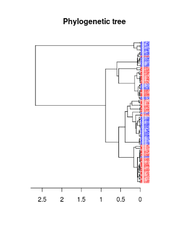

By default, `plot.null.dist` is set to `TRUE`.

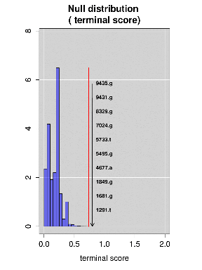

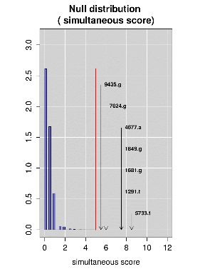

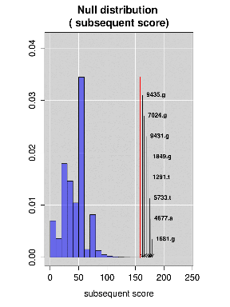

By default, `plot.manhattan` is also set to `TRUE`.

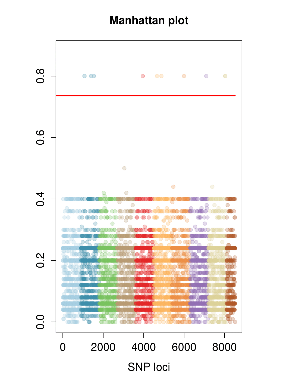

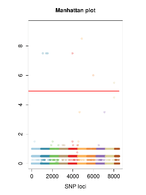

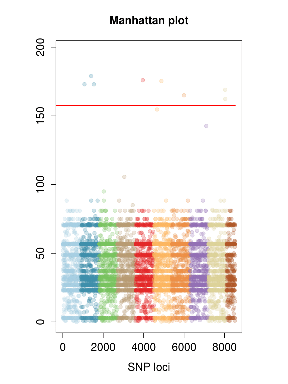

### Printing Output

In the example above, the output of the `treeWAS` function was assigned to an object called `out`. It is a *large* object. As such, we recommend that the `print.treeWAS` function be used to examine the set of results identified (NB: `print.treeWAS` is just the `print` function for an object of class `treeWAS`):

```r
print(out, sort.by.p=FALSE)
```

```
##  ####################
##  ## treeWAS output ##
##  ####################
##
##  ####################
##  ## All findings:  ##
##  ####################
## Number of significant loci: [1] 10
## Significant loci:
##  [1] "1291.t" "1681.g" "1849.g" "4677.a" "5495.g" "5733.t" "7024.g"
##  [8] "8329.g" "9431.g" "9435.g"
##
##  ########################
##  ## Findings by test:  ##
##  ########################
##   ####################
##   ##  terminal test ##
##   ####################
## Number of significant loci:
## [1] 10
## Significance threshold:
## 99.99996%
##      0.76
## Significant loci:
##        SNP.locus p.value score G1P1 G0P0 G1P0 G0P1
## 1291.t      1170       0   0.8   49   41    4    6
## 1681.g      1528       0   0.8   49   41    4    6
## 1849.g      1679       0   0.8   49   41    4    6
## 4677.a      4289       0  -0.8    3    7   38   52
## 5495.g      5049       0   0.8   48   42    3    7
## 5733.t      5274       0   0.8   50   40    5    5
## 7024.g      6485       0   0.8   49   41    4    6
## 8329.g      7686       0   0.8   48   42    3    7
## 9431.g      8698       0   0.8   50   40    5    5
## 9435.g      8702       0   0.8   51   39    6    4
##   ########################
##   ##  simultaneous test ##
##   ########################
## Number of significant loci:
## [1] 7
```

[output cut: 14 more lines]

[output not shown]

### Writing Output to CSV

The results contained in the output of `treeWAS` can also be saved in a CSV file. The `write.treeWAS` function will write a summary table to CSV, containing the names and loci of all significant findings, as well as their scores and p-values, as well as the cells of a 2x2 contingency table of genotype and phenotype if the phenotype is binary.

All that is required is to run the `write.treeWAS` function and specify a file name to which the “.csv” file will be saved. By default, the `filename` argument is “./treeWAS_results”. The “./” prefix means that by default the file will be saved to the current working directory, “~/” will save to the home directory, or you can specify a path explicitly ahead of the desired file name. You can see an example by running the following command on the output from the example above (the object called `out`):

```r
write.treeWAS(out, filename="./treeWAS_results")
```

### Output Returned

The output of `treeWAS` contains the set of significant loci identified as well as all relevant information used by or generated within `treeWAS`. The `treeWAS` function returns a list object (in our example, called `out`), which takes on the following general structure (run `str(out)` to examine the structure of our example output):

**$treeWAS.combined**, the first element, is a list of length two containing the identities of significant findings:

> **`$treeWAS.combined`**

> The pooled set of significant loci identified by any association score.

> **`$treeWAS`**

> A list with the sets of significant loci identified by each association score individually.

**$[SCORE]**, list elements for each association score, contain the original score values for each locus and additional information for significant loci. By default, there will be three such `$[SCORE]`-type elements called `$terminal`, `$simultaneous`, and `$subsequent`, each of which will have the following elements:

> **`$corr.dat`**

> The association score values for loci in the empirical genetic dataset.

> **`$corr.sim`**

> The association score values for loci in the simulated genetic dataset.

> **`$p.vals`**

> The p-values associated with the loci in the empirical genetic dataset for this association score.

> **`$sig.thresh`**

> The significance threshold for this association score.

> **`$sig.snps`**

> A data frame describing the genetic loci identified as significant. The last four columns will only be present if the data is binary, in which case they will contain the cell counts of a 2x2 table of genotypic and phenotypic states for each significant locus.

> `row.names`: The column names of significant loci.

> `$SNP.locus`: The column positions of significant loci in `dat$snps` (see below).

> `$p.value`: The p-values for significant loci.

> `$score`: The association score values for significant loci.

> `$G1P1`: The number of individuals with genotype = 1 and phenotype = 1 at this locus.

> `$G0P0`: The number of individuals with genotype = 0 and phenotype = 0 at this locus.

> `$G1P0`: The number of individuals with genotype = 1 and phenotype = 0 at this locus.

> `$G0P1`: The number of individuals with genotype = 0 and phenotype = 1 at this locus.

> **`$min.p.value`**

> The minimum p-value. P-values listed as zero can only truly be defined as below this value.

**$dat**, the final element, contains all of the data either used by or generated within `treeWAS`. Objects that were provided as inputs to the `treeWAS` function will be returned here in the form in which they were analysed (i.e., after data cleaning within `treeWAS`).

> **`$snps`**

> The empirical genetic data matrix.

> **`$snps.reconstruction`**

> The ancestral state reconstruction of the empirical genetic data matrix.

> **`$snps.sim`**

> The simulated genetic data matrix.

> **`$snps.sim.reconstruction`**

> The ancestral state reconstruction of the simulated genetic data matrix.

> **`$phen`**

> The phenotypic variable.

> **`$phen.reconstruction`**

> The ancestral state reconstruction of the phenotype.

> **`$tree`**

> The phylogenetic tree.

> **`$n.subs`**

> The homoplasy distribution. Each element represents a number of substitutions (from 1 to `length(n.subs)`) and contains the number of loci that have been inferred to undergo that many substitutions.

## Integration with ClonalFrameML

The *treeWAS* R package has also been designed to work with the output of ClonalFrameML. By using the simple `read.CFML` function, you can convert the output of ClonalFrameML into a form suitable for input into `treeWAS`.

### The Data

For practice using ClonalFrameML, [download](http://www.danielwilson.me.uk/files/cfml.tgz) the ClonalFrameML example data and follow the steps on the wiki to arrive at the `example.output` dataset. To run the example below, replace the prefix with the path to the `example.output` dataset on your computer or to another set of output from ClonalFrameML containing:

1. “prefix.labelled_tree.newick”
2. “prefix.ML_sequence.fasta”
3. “prefix.position_cross_reference.txt”

### Convert the Data

To convert the data, use the `read.CFML` function:

```r
prefix <- "./example.output"
dat <- read.CFML(prefix=prefix)
```

Isolate the elements of the output of `read.CFML`:

```r
## Required input into treeWAS:
snps <- dat$snps

## Recommended input into treeWAS:
tree <- dat$tree

## Optional input into treeWAS:
n.subs <- dat$n.subs
snps.rec <- dat$snps.rec
```

### Input & Arguments

You can now run `treeWAS` using this `snps` matrix, and the `tree` returned from `read.CFML`.

Instead of supplying `snps.rec` to the argument `snps.reconstruction`, it may be worth (re-)creating the ancestral state reconstruction within `treeWAS`. This is recommended, provided the dataset you are working with is not extremely large, in case any inconsistencies exist between the reconstruction performed by ClonalFrameML and that run within `treeWAS` (which will also be applied to the simulated null dataset).

The `dist` object can be provided in the `n.subs` argument, though you may also leave this `NULL` and have `treeWAS` recreate `n.subs` internally, again in case there is any discrepancy between the internal and external methods or reconstruction.

All you would need to run `treeWAS` with this example dataset is a phenotype. We can make a toy phenotype for this purpose, although no significant findings should result:

```r
set.seed(1)
phen <- sample(c(0,1), nrow(snps), replace=TRUE)
phen <- as.factor(phen)
names(phen) <- rownames(snps)

## Exmine toy phenotype
str(phen)
table(phen)
```

### Running treeWAS

You can now run `treeWAS` using the converted ClonalFrameML output:

```r
## Example not run...
out <- treeWAS(snps = snps,
                phen = phen,
                tree = tree,
                n.subs = NULL,  ## (optional input: n.subs)
                n.snps.sim = ncol(snps)*10,
                chunk.size = ncol(snps),
                test = c("terminal", "simultaneous", "subsequent"),
                snps.reconstruction = "parsimony",  ## (optional input: snps.rec)
                snps.sim.reconstruction = "parsimony",
                phen.reconstruction = "parsimony",
                phen.type = NULL,
                na.rm = TRUE,
                p.value = 0.01,
                p.value.correct = "bonf",
                p.value.by = "count",
                dist.dna.model = "JC69",
                plot.tree = TRUE,
                plot.manhattan = TRUE,
                plot.null.dist = TRUE,
                plot.dist = FALSE,
                snps.assoc = NULL,
                filename.plot = NULL,
                seed = 1)
```

## Bugs & Features

### Report a Bug

The *treeWAS* R package is still in its early days. As such, you may encounter an error before we do. If you believe you have identified a bug, or you are unable to overcome an error after consulting the documentation, we encourage you to visit our [Issues Page](https://github.com/caitiecollins/treeWAS/issues). If your issue has not been documented by another user, please [Post A New Issue](https://github.com/caitiecollins/treeWAS/issues/new).

### Request a Feature

There may be a feature absent from *treeWAS* that you wish could be performed by the R package. We welcome your suggestions and invite you to [Place a Feature Request](https://github.com/caitiecollins/treeWAS/issues/new) on our [Issues Page](https://github.com/caitiecollins/treeWAS/issues).

We are working towards a number of features in the near future, for example, allowing *treeWAS* to handle non-binary categorical phenotypes.